# Flux-based hierarchical organization of *Escherichia coli*'s metabolic network

Semidán Robaina-Estévez* and Zoran Nikoloski

Systems Biology and Mathematical Modeling Group. Max Planck Institute of Molecular Plant Physiology. Bioinformatics Group, University of Potsdam, Potsdam, Germany

This notebook contains the workflow used to generate the results presented in the accompanying paper: Robaina-Estévez and Nikoloski (2019). Specifically, we find and analyze the flux-ordered reaction pairs in *E. coli*'s genome-scale metabolic model iJO1366 under growth in three carbon sources: glucose, glycerate and acetate. Further, we reconstruct the directed acyclic graph (DAG) which represents the flux-order relation and analyze which metabolic subsystems are predominant in each graph level. Finally, we evaluate whether diverse experimental measurements—such as ${}^{13}\mathrm{C}$-estimated fluxes, protein and transcript levels—reflect the predicted flux-order relation. For more detailed information about the results and the methods employed we refer the reader to the accompanying paper. Let's get started!

**General notes:**: First, there are several interactive figures in the notebook. These figures require the notebook to be trusted to work — unless you are seeing this notebook as a web page, in this case ignore this message. All interactive figures have been generated using modified code from [Jupyter's ipywidgets.](https://github.com/Robaina/ipywidgets-static) Second, some of the computations in this notebook can take time, however, it is not necessary to run the notebook to see the interactive figures, since they work even without a kernel. Third, the notebook requires all the files found in the [GitHub repository](https://github.com/Robaina/fluxOrders/Robaina_Nikoloski_2019) plus the data files retrieved from the sources cited in the paper. For reproducibility, a copy of these files can be accessed from this [DropBox repository](https://www.dropbox.com/sh/ou9zooplfx3y7sh/AACLwpf6iO1EpystFU1vdQ82a?dl=0), data files must be place in the project directory: Data. The notebook requires the python libraries found in *requirements.txt* in order to be run.

*corresponding author: hello@semidanrobaina.com

```python
# Import required libraries
import pandas as pd
import numpy as np
import copy
import networkx as nx
from scipy import cluster, spatial
from matplotlib import pyplot as plt
from cobra.flux_analysis.variability import find_essential_reactions
from matplotlib_venn import venn3_unweighted
from IPython.display import display, Markdown, HTML
plt.style.use('seaborn')

# Import own modules
from Data_module import DataParser
from Model_module import Model
from Order_module import FluxOrder, DataOrderEvaluator, getFluxOrderDataFrame
import Helper_methods as hm
import Plot_methods as pm

carbonSources = ['glucose', 'glycerate', 'acetate']
n_sources = len(carbonSources)
workDir = 'path_to_cloned_repository'
%matplotlib inline
```

# 1. The flux order relation in *Escherichia coli*

In this first section, we begin by importing the iJO1366 model and setting the correct environmental conditons for the three carbon sources evaluated: glucose, glycerate and acetate. We then continue finding the flux-ordered reaction pairs of iJO1366 in the three carbon sources. Next, we compare the sets of flux-ordered reactions among carbon sources, to evaluate to which extent the flux order relation depends on environmental conditions. Finally, we will analyze the overlap between the sets of flux-ordered reaction pairs and flux-coupled reaction pairs since they do share some properties.

## 1.1. Creating model instancies for the three carbon sources

We begin by importing the iJO1366 model into the cobrapy toolbox, we will process the model to remove blocked reactions—i.e., reactions that cannot carry flux in any steady state—and to split reversible reactions into the two possible directions: forward and backward (here tagged as reverse). The class Model found in *Model_module* of this study provides all the required methods. In all three cases, we simulate the growth of *E. coli* in a minimal medium with a single carbon source, to this end, we neglect the import of any organic compound besides the carbon source and cobalamine (vitamin B12), since *E. coli* cannot synthetize it. We set the maximum carbon source uptake flux to be 20 $\mathrm{mmol.L}^{-1}.\mathrm{min}^{-1}$, and constraint the flux through the biomass reaction to be at least 95% of the maximum flux possible under the given constraints. Note that we include an additional environmental condition, *all*, in which the model is allowed to take any of the three carbon sources here evaluated, we will use this additional setting later on.

```python
# Prepare Models for the three carbon sources
iJO1366 = {}
temp = Model(fileName='iJO1366.json', workDir=workDir + '/Models/iJO1366')
for carbonSource in carbonSources + ['all']:
    print(' ')
    print('Preparing model for carbon source: {}'.format(carbonSource))
    temp.setCarbonSource(carbonSource, uptakeRate=20, fractionOfBiomassOptimum=0.95)
    iJO1366[carbonSource] = copy.deepcopy(temp)
```

```
Split GEM generated with 2100 non-blocked reactions and 1155 metabolites

Preparing model for carbon source: glucose
Maximizing: BIOMASS_Ec_iJO1366_WT_53p95M, E. coli biomass objective function (iJO1366) - WT - with 53.95 GAM estimate
Maximum growth rate under glucose: 1.986149098710268 h^{-1}

Preparing model for carbon source: glycerate
Maximizing: BIOMASS_Ec_iJO1366_WT_53p95M, E. coli biomass objective function (iJO1366) - WT - with 53.95 GAM estimate
Maximum growth rate under glycerate: 0.753889646704215 h^{-1}

Preparing model for carbon source: acetate
Maximizing: BIOMASS_Ec_iJO1366_WT_53p95M, E. coli biomass objective function (iJO1366) - WT - with 53.95 GAM estimate
Maximum growth rate under acetate: 0.5084981153029655 h^{-1}

Preparing model for carbon source: all
Maximizing: BIOMASS_Ec_iJO1366_WT_53p95M, E. coli biomass objective function (iJO1366) - WT - with 53.95 GAM estimate
Maximum growth rate under acetate: 20.748004213608066 h^{-1}
```

## 1.2. Finding flux-ordered reaction pairs

Now that we have prepared the iJO1366 model, we proceed to find all flux-ordered reaction pairs for the three carbon sources. That is, for each reaction pair $r_i,r_j$ in the model we want to test whether their fluxes satisfy $v_i \geq v_j, \forall v \in C = \{v:Sv=0,v_{min} \leq v \leq v_{max}\}$ (see accompanying paper for details). To this end, we employ a simple linear program which maximizes the flux ratio of a pair of reactions. Specifically, we start with the linear-fractional program

\begin{align} \begin{aligned} &z_{max} = \max_v \; \frac{v_j}{v_i} \\ &\mathrm{s.t.} \\ &Sv=0 \\ &v_{min} \leq v \leq v_{max} \end{aligned} \label{eq:1} \end{align}

and apply the Charnes-Cooper transformation to obtain the linear program

\begin{align} \begin{aligned} &z_{max} = \max_{w,t} \; w_j \\ &\mathrm{s.t.} \\ &Sw = 0 \\ &w_i = 1 \\ &tv_{min} \leq w \leq tv_{max} \\ &t \geq 0 \end{aligned} \label{eq:2} \end{align}

in which $w_j = \frac{v_j}{v_i}$. A reaction pair is then flux-ordered if $z_{max} \leq 1$. However, repeating this process for all possible reaction pairs in the model is computationally intensive, since the number of pairs grows as $\frac{1}{2} n(n-1)$ where $n$ is the number of reactions in the model. To speed up the computation time, we first apply a less computationally expensive process in which we discard reaction pairs that cannot be flux-ordered. Specifically, we draw a number of random flux samples for all reactions in the model, then we discard reaction pairs for which in at least one of the samples the flux order relation is not satisfied. Additionally, we can further narrow down the set of candidate pairs through flux variability analysis (FVA) as follows . First, we compute the flux distributions which maximize each reaction flux in the model. Let $w$ be the flux distribution that maximizes the flux through $r_j$, i.e. $w_j = v_{max(j)}$. If $v_i \geq v_j$ truly holds, then $w_j \leq w_i$, i.e., even at the flux distribution that maximizes $v_j$, reaction $r_i$ carries a larger or equal flux $w_i$. We call the remaining reaction pairs *candidate flux-ordered*, which we further test with the previous linear program to assess whether or not they really are flux-ordered.

```python
# Find candidate flux-ordered reaction pairs
iJO1366['glucose'].findCandidatePairs(nsamples=5000, fva_filter=True)
```

```
Finding candidate ordered reaction pairs
There are: 460570 candidate pairs out of 2203950.0 total pairs
```

Unlike flux coupling relations, the flux order relation depends on the flux bounds of each reactions. For instance, in the following interactive figure, we depict the steady-state flux space for two reactions $r_i, r_j$, which is delimited by the two constraints drawn in red and blue. Every flux pair above the dashed line representing $v_i = v_j$ satisfies $v_i > v_j$. Now, the adjustable golden line depicts the flux upper bound of reaction $v_j$. We see that only when the upper bound reaches a value of 400 the reaction pair becomes flux-ordered, since the feasible region, shaded in grey, lays entirely above the dashed line. This dependency of the flux-order relation of the flux bounds is also the reason why different sets of flux-ordered pairs may be found under different simulated conditions, such as the three carbon sources evaluated here.

```python
# Plot example
pm.plotOrderExample(min_flux=0, max_flux=1000, range_step=100,
                    default_value=600, description='$v_j^{ub}$')
```

**$v_j^{ub}$** = 600

[figure not shown]

Now that we have found the candidate flux-ordered pairs, we are ready to evaluate which of the candidates are truly ordered. Solving the previously presented linear program for each of the candidate pairs is an [embarrassingly parallel](https://en.wikipedia.org/wiki/Embarrassingly_parallel) task, hence, we employ the [Gurobi](http://www.gurobi.com/) in a parallel setting using the R programming language. To this end, we can call the supplied R function *get_flux_orders*, found in Rfunctions.R, through python using the *rpy2* module

```
fluxOrders_A = get_flux_orders(S, lb, ub, candidatePairs)
```

which returns the adjacency matrix of the directed acyclic graph representing the flux order relation, that is, the entry $a_{ij} = 1$ if $v_i \geq v_j$ and $a_{ij} = 0$ otherwise. Alternatively, we directly call the function within R. To this end, we need to export the stoichiometric matrix $S$, flux bounds $lb, ub$ and the array containing the candidate pairs to csv using the *exportToCSV* method of the *Model* class, that is, we would call

```
model_attributes = ['S', 'lb', 'ub', 'candidatePairs']
for carbonSource in carbonSources:
    iJO1366[carbonSource].exportToCSV(attributes=model_attributes, directory=path_to_directory)
```

which would create the files: 'S_carbonSource.csv', 'ub_carbonSource.csv', 'lb_carbonSource' and 'candidatePairs_carbonSource.csv'. We would proceed to import the csv files in R and call the function (see the documentation within 'Rfunctions.R' for an example). While this procedure is a bit more cumbersome, calling *get_flux_orderes* directly within R increases performance. Finding all flux-ordered pairs (directly within R) took around 5 hours using a laptop with 4 cores (8 threads) for each carboun source. To accelerate this process, we will employ the already computed adjacency matrices for each of the three carbon sources.

```python
# Upload adjacency matrices for each carbon source
iJO1366_A = {}
for carbonSource in carbonSources:
    iJO1366_A[carbonSource] = np.genfromtxt(workDir + '/Data/Models/iJO1366/iJO1366_AdjMat_'
                                            + carbonSource + '.csv', delimiter=',')
```

## 1.3. Comparing the flux-ordered pairs among the three carbon sources

Here, we analyze the similarities and differencies among the sets of flux-ordered reaction pairs corresponding to the three carbon sources. First of all, we will compare the total number of flux-ordered pairs, then, generate a Venn diagram to show the extent to which flux-ordered reaction pairs are shared among carbon sources. We will also compute the Jaccard distance between each set of flux-ordered pairs and plot a dendrogram to further visualize the differences. Let's plot the total number of flux-ordered pairs, then.

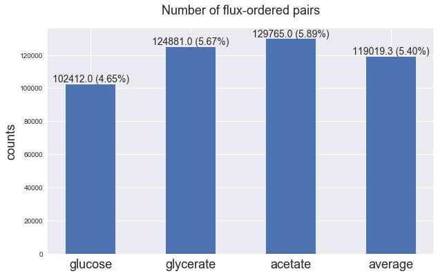

```python
# Count number of ordered pairs per carbon source
number_pairs, ordered_pairs = {}, {}
for carbonSource in carbonSources:
    ordered_pairs[carbonSource] = set(np.where(iJO1366_A[carbonSource].flatten() == 1)[0])
    number_pairs[carbonSource] = len(ordered_pairs[carbonSource])
number_pairs['average'] = np.mean([number_pairs[source] for source in carbonSources])


# Plot bar plot with total counts
n_rxns = iJO1366['all'].numberOfReactions

number_total_pairs = 0.5 * n_rxns * (n_rxns - 1)
plt.figure(figsize=(10, 6))
bars = plt.bar(range(n_sources + 1), number_pairs.values(),
               width=0.5, tick_label=list(number_pairs.keys()))
plt.xticks(fontsize=18)
plt.ylabel('counts', fontsize=18)
plt.title('Number of flux-ordered pairs', fontsize=18, pad=20)

# Add counts above the bars
for bar in bars:
    height = bar.get_height()
    bar_text = '%.1f' % height + ' (' + '%.2f' % (100 * height / number_total_pairs) + r'%)'
    plt.text(bar.get_x() + bar.get_width()/2.0,
             height, bar_text, ha='center', va='bottom', fontsize=14)


plt.show()
```

We see that glucose is the carbon source that produces the least number of flux-ordered reaction pairs, while acetate the largest number. While the number of flux-ordered pairs is quite large on average, it only supposes a 5.4% of the total number of reaction pairs in the iJO1366 model. Let's now delve into the differences and similarities among the carbon sources. We begin by constructing a Venn diagram to visualize the intersection structure among the three sets.

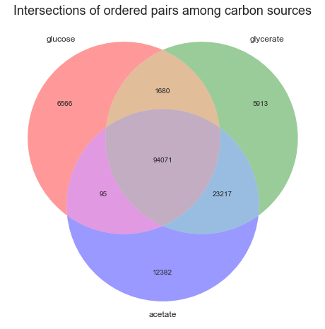

```python
# Plot Venn diagram depicting sets of flux-ordered pairs
plt.figure(figsize=(8, 8))
plt.title('Intersections of ordered pairs among carbon sources', fontsize=18)
venn3_unweighted(ordered_pairs.values(), ordered_pairs.keys())
plt.show()
```

```python
# Fraction of shared ordered pairs per carbon source
number_shared_pairs = 94071
print('Fraction of shared ordered pairs per carbon source:')
for carbonSource in carbonSources:
    print('{}: {:.2f}%'.format(carbonSource, 100 * (number_shared_pairs / number_pairs[carbonSource])))
```

```
Fraction of shared ordered pairs per carbon source:
glucose: 91.86%
glycerate: 75.33%
acetate: 72.49%
```

We can see in the Venn diagram that a large number of flux-ordered reaction pairs are shared among the three carbon sources. However, with respect to the total number of pairs of each carbon source, we see that, in the case of glucose, the set of shared pairs supposes as much as 91.86% of the total pairs, while this figure is lower for acetate and glycerate, 72.49% and 75.33%, respectively. That is, the majority of the flux-ordered pairs in the glucose escenario are contained in the other two carbon sources. Additionally, acetate and glycerate do share a marked number of flux-ordered pairs, altough acetate is the carbon source with the largest number of exclusice flux-ordered pairs.

Altogether, the previous results indicate that the sets of flux-ordered pairs generated under acetate and glycerate seem to be more similar to one another than to the ones generated under glucose, in fact almost a superset of the latter. We can further visualize the similarities between carbon sources through a dendrogram. We will use the [Jaccard index](https://en.wikipedia.org/wiki/Jaccard_index) as a distance between the sets of flux-ordered pairs among carbon sources.

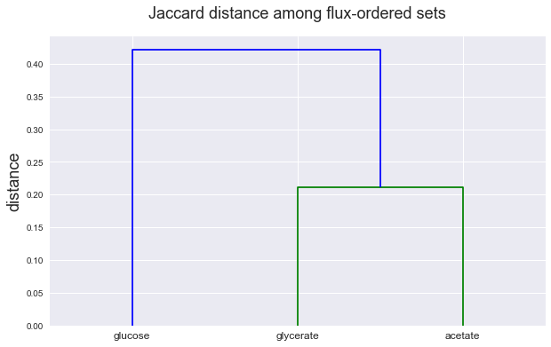

```python
# Reconstruct the Jaccard distance matrix
iJO1366_D = pd.DataFrame(np.zeros((n_sources, n_sources)),
                         index=carbonSources, columns=carbonSources)
for carbonSource1 in carbonSources:
    for carbonSource2 in carbonSources:
        dist = spatial.distance.jaccard(
            iJO1366_A[carbonSource1].flatten(), iJO1366_A[carbonSource2].flatten())
        iJO1366_D[carbonSource1][carbonSource2] = dist

# Plot dendrogram of Jaccard distance
Z = cluster.hierarchy.linkage(1 - iJO1366_D.values, 'single')
plt.figure(figsize=(10, 6))
plt.title('Jaccard distance among flux-ordered sets', fontsize=18, pad=20)
plt.ylabel('distance', fontsize=18)
cluster.hierarchy.dendrogram(Z, labels=iJO1366_D.columns)
plt.show()
```

## 1.4. Analyzing the overlap with flux coupling relations

Flux coupling relations establish constraints between the activity patterns, i.e., whether or not they carry non-zero flux, of reaction pairs in a genome-scale model. Specifically, two reactions, $r_i, r_j$ are fully or partially coupled if the two reactions are always active or always inactive in any steady state. With the difference that fully coupled reactions also have a fixed flux ratio when active, i.e., $\frac{v_i}{v_j} = \alpha$ for a fixed $\alpha$. Both, the fully coupled relation, represented as $r_i \Leftrightarrow r_j$, and the partially coupled relation, represeted as $r_i \leftrightarrow r_j$ are symmetric. Contrary, in the directional coupling relation, one (leading) reaction controls the activation state of another reaction, thus this relation is asymmetric, i.e., $r_i \rightarrow r_j$.

Flux coupling relations share some similarities with the flux order relation. To start with, they are both a consequence of network topology and the steady-state constraint. Further, the directional coupling relation is also asymmetric and hence also induces a partially ordered set (i.e., a hierarchy) which can be represeted by a DAG. (The other two coupling relations: full and partial, are symmetric and thus cannot form a DAG.) However, contrary to the flux-order relation, flux-coupling relations are not affected by the particular flux bounds impose on the reactions, that is, as long as reactions are not rendered inactive by the flux bounds. Because of this, we only generate one set of flux-coupled reaction pairs which is the same for the three carbon sources.

Here, we will study to which extend flux coupled reaction pairs overlap with the identified flux-ordered pairs. First, we need to find the flux couple relations in our model, iJO1366. F2C2 is an efficient tool for this task. Unfortunately, it's been only implemented in MATLAB. For this reason, we need to upload here a pre-computed matrix (obtained through F2C2 in MATLAB) which identifies the flux coupled pairs among all reaction pairs in iJ1366. The entry code is the following, for each reaction pair $r_i, r_j$, we have

- $a_{i,j} = 0$ -> uncoupled
- $a_{i,j} = 1$ -> fully coupled
- $a_{i,j} = 2$ -> partially coupled
- $a_{i,j} = 3$ -> directionarlly coupled

After obtaining the sets of flux coupled reaction pairs, we will compute the fraction of flux-ordered pairs that are also fully, partially and directionally coupled. Similarly, we will compute the fraction of partially and directionally coupled pairs that are also flux-ordered. Note that all fully coupled pairs are flux-ordered because their ratio is fixed. First, let's compare the sizes of the sets of flux-ordered and flux-coupled reactions.

```python
# Upload flux coupling relations matrix
iJO1366_fctable = np.genfromtxt(
   workDir + '/Data/Models/iJO1366/fc' + 'iJO1366' + '.csv', delimiter=',')

# Compute fraction of coupled pairs (all three types)
nrxns = np.size(iJO1366_fctable, 0)
number_reaction_pairs = 0.5 * nrxns * (nrxns - 1)
number_coupled_pairs = (len(np.where(iJO1366_fctable > 0)[0]) - nrxns) / 2
coupled_fraction = 100 * (number_coupled_pairs / number_reaction_pairs)

print('There are {coupled} coupled pairs out of a total of {total}. That is a fraction of {fraction:.2f}%'.format(
    coupled=int(number_coupled_pairs), total=int(number_reaction_pairs), fraction=coupled_fraction))
```

```
There are 42114 coupled pairs out of a total of 2203950. That is a fraction of 1.91%
```

To begin with our comparison, we see that there are more flux-ordered reaction pairs than flux-coupled reaction pairs. Remember, that we saw before that, on average, the fraction of flux-ordered pairs across carbon sources was 5.40%, while the fraction of all types of flux-coupled pairs (for the three carbon sources) is 1.91%. Let's now look at the overlap between the sets of flux-ordered and flux-coupled reactions. We will plot pie charts for each carbon source depicting the fraction of flux-ordered reactions that are also fully, partially and directionally coupled.

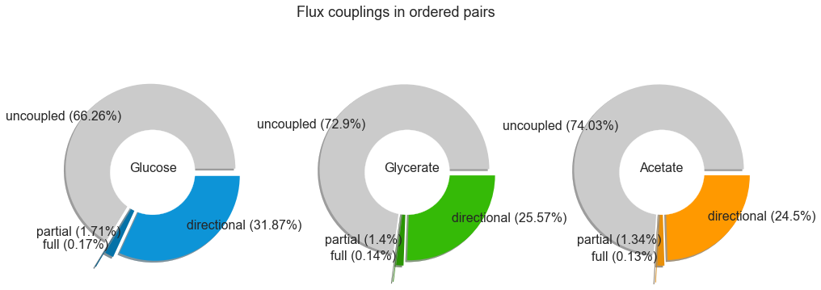

```python
# Find fractions and plot pie charts
fig, axs = plt.subplots(nrows=1, ncols=3, sharex=False, sharey=False, figsize=(16, 6))
plt.suptitle('Flux couplings in ordered pairs', fontsize=18)
colors = [ ['#cbcbcb', '#005b88', '#0572a8', '#0d94d7'],
          ['#cbcbcb', '#237506', '#299404', '#35ba07'],
          ['#cbcbcb', '#cf7e04', '#e88f09', '#ff9900'] ]

coupled_ordered, iJO1366_Orders = {}, {}
for i, carbonSource in enumerate(carbonSources):
    iJO1366_Orders[carbonSource] = FluxOrder(iJO1366[carbonSource],
        iJO1366_A[carbonSource], iJO1366_fctable)

    # Get fraction of coupled pairs that are also ordered
    coupled_ordered[carbonSource] = iJO1366_Orders[carbonSource].evaluateFluxCouplingRelations(
        axs[i], colors[i])['fraction ordered coupled']

plt.subplots_adjust(hspace=0)
plt.show()
```

We see in the pie charts that the majority of flux-ordered pairs are not flux-coupled in all three carbon sources, with acetate being the carbon source in which less ordered pairs are also coupled. Therefore, the flux order relation is not contained in the flux coupling relations. Further, almost all flux-ordered and flux-coupled pairs are *directionally* coupled in all three cases. Let's see next what fraction of partially and directionally coupled pairs are also flux-ordered.

```python
# Get fraction of coupled pairs that are also ordered
df = pd.DataFrame.from_dict(coupled_ordered)
display(HTML(df.to_html()))
```

|  | glucose | glycerate | acetate |
| --- | --- | --- | --- |
| directional | 83.14200 | 81.34400 | 80.98200 |
| partial | 92.78500 | 92.52000 | 92.36100 |
| total | 81.57802 | 79.89943 | 79.55238 |

```python
print('Mean proportion of coupled pairs that are ordered across carbon sources:')
for coupling_type in ['partial', 'directional']:
    print('{} and ordered: {:.2f}%'.format(coupling_type, np.mean(
        [coupled_ordered[source][coupling_type] for source in carbonSources])))
```

```
Mean proportion of coupled pairs that are ordered across carbon sources:
partial and ordered: 92.56%
directional and ordered: 81.82%
```

# 2. Analyzing the flux order DAG.

In this section, we reconstruct the flux order directed acyclic DAGs for the three carbon sources from the adjacency matrices obtained before. We first analyze some basic features of the DAGs such as the number of levels in the hierarchy and the distribution of reactions per graph level. We include an example of a flux-ordered reaction chain obtain from one of the DAGs. We then proceed to display the distribution of reaction metabolic subsystems and macrosystems per graph level.

## 2.1. Reconstructing the flux order DAG

Let's start by extracting all the reactions in each of the levels of the flux order graph and per each carbon source. We will then plot a histogram depicting the number of reactions per level and carbon source

```python
# Generate the graph of the Hasse diagram through networkx
Graph_Levels, iJO1366_Orders_DAG = {}, {}
for carbonSource in carbonSources:
    iJO1366_Orders_DAG[carbonSource] = iJO1366_Orders[carbonSource].getGraph()
    Graph_Levels[carbonSource] = iJO1366_Orders_DAG[carbonSource].getGraphLevels()
```

```
Extracting reactions in flux order DAG levels...
Extracting reactions in flux order DAG levels...
Extracting reactions in flux order DAG levels...
```

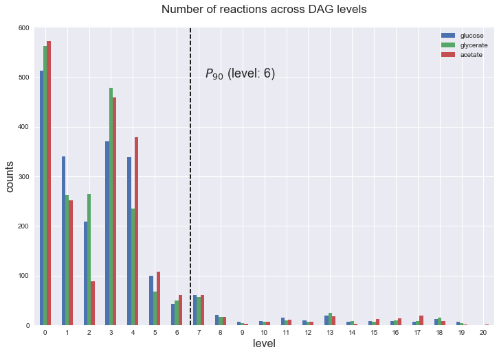

```python
rxn_distribution = pm.plotNumberOfReactionsPerGraphLevel(Graph_Levels)
```

We can see that the first levels, i.e. those in which reactions tend to impose an upper flux bound to the larger number of reactions, accumulate the majority of reactions involved in a flux order relation. Additionally, we observe no large differences among carbon sources. Acetate produces a graph with an additional level. Let's now plot a stacked bar plot depicting the representation of each metabolic macrosystem in the entire set of ordered reaction pairs for each carbon source.

## 2.2. An interactive flux order DAG of *E. coli*'s core network

The flux order DAG obtained using the complete metabolic network in iJO1366 is too large to be visualized in any meaningful way. To help with this issue, we prepared a a flux order DAG of a smaller metabolic network, [EColiCore2](https://www.nature.com/articles/srep39647) which contains the core part, i.e., the central carbon metabolism, of the iJO1366 model. Additionally, EColiCore2 maintains the same solution space at steady state (hence, same flux ordered reaction pairs) as iJO1366. For an interactive app of the flux order DAG of *E. coli*'s core metabolic network under growth on glucose click on the following image:

[figure not shown]

## 2.3. An illustration of a flux-ordered chain

```python
# Extract random ordered chain
example_source = 'acetate'
source_rxn_id = 'AKGDH'
chain_length = 5
orderedChain = iJO1366_Orders_DAG[example_source].getOrderedReactionChain(
    source=source_rxn_id, size=chain_length)

# Print reaction chain
rxn_names = str()
sample_chain_list = []
for multiple_rxn_ids in orderedChain:
    rxn_ids = multiple_rxn_ids.split(r'||')
    random_idx =  np.random.randint(len(rxn_ids))
    sample_chain_list.append(rxn_ids[random_idx])
    if len(rxn_ids) > 1:
        eq_rxn_names = '('
        for rxn_id in rxn_ids:
            eq_rxn_names += 'r_{' + rxn_id + '} = '
        eq_rxn_names = eq_rxn_names[:-3] + ')'
    else:
        eq_rxn_names = 'r_{' + rxn_ids[0] + '}'
    rxn_names += eq_rxn_names + r' \ge '

display(Markdown('__Ordered reaction chain__: <br>'+ '$' + rxn_names[:-4] + '$'))
```

**Ordered reaction chain**:  
$r_{AKGDH} \ge r_{ACCOAC} \ge r_{3HAD100} \ge r_{3HAD121} \ge r_{EAR121y} $

We see that the root of this chain is reaction AKGDH (2-Oxogluterate dehydrogenase) while the sink, i.e., the last reaction in the chain, is reaction EAR121y (Enoyl-[acyl-carrier-protein] reductase). Hence, AKGDH must have the largest flux value and EAR121y the smallest of the chain in any steady state of the system. Note that some groups of reactions in the chain may carry equal fluxes (depicted within parentheses). These reactions are fully coupled among each other, with a couplig constant, i.e., a fixed flux ratio, of 1.

Let's now draw a random sample of flux distributions to certify that the flux levels of the reactions follow the flux-ordered chain structure presented above. To guarantee that the flux through the root reaction is non-zero in the same, we will constraint the lower flux bound of this reaction to a fraction of its theoretical maximum. We will then plot the sampled flux values for the reactions in the chain, to this end, we will pick one representative reaction from each group of fully coupled reactions

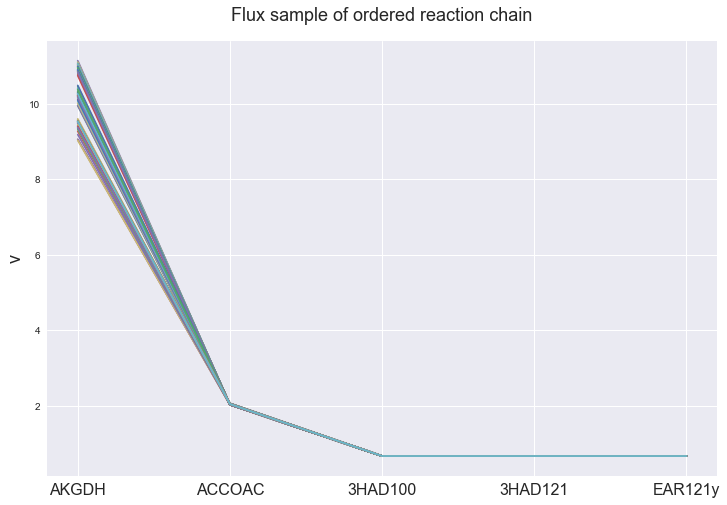

```python
pm.plotFluxSampleOfOrderedChain(iJO1366[example_source], sample_chain_list)
```

We see that, as it must be, the sampled fluxes follow the order relation displayed in the flux-ordered reaction chain.

## 2.4. Representation of metabolic systems in the Hasse diagram

Until now, we have only cared about the similarities and differences in then numbers of flux-ordered reaction pairs as well as the sets themselves among carbon sources. Next, we will analyze which metabolic subsystems and macrosystems are represented in each level of the flux order DAG of each carbon source. While metabolic subsystems are those contained in the iJO1366 model, the macrosystems 8 broader metabolic categories which have been assigned to the subsystems of iJO1366 in this study (see Supplementary Table 1). We begin by computing the representation of the 8 macrosystems across graph levels for the three carbon sources. Specifically, we will look at the frequencies fo the macrosystems, i.e., the fraction of reactions in the DAG that have each macrosystem assigned, in the set of shared reactions among the three DAGs as well as the sets of exclusive reactions corresponding to each carbon source.

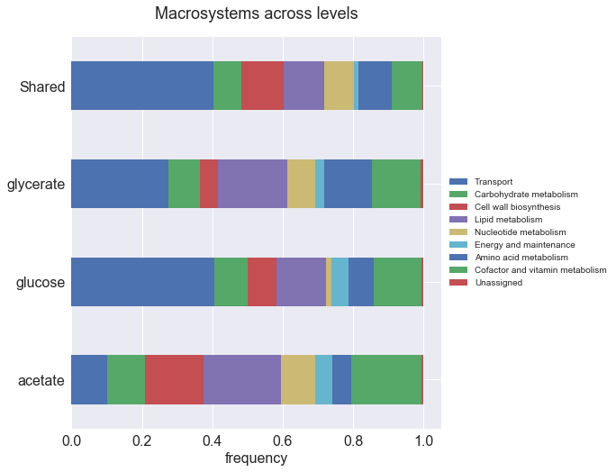

|  | Transport | Carbohydrate metabolism | Cell wall biosynthesis | Lipid metabolism | Nucleotide metabolism | Energy and maintenance | Amino acid metabolism | Cofactor and vitamin metabolism | Unassigned |
| --- | --- | --- | --- | --- | --- | --- | --- | --- | --- |
| acetate | 0.10233 | 0.10698 | 0.16512 | 0.22093 | 0.09767 | 0.04884 | 0.05349 | 0.20000 | 0.00465 |
| glucose | 0.40523 | 0.09477 | 0.08170 | 0.14052 | 0.01634 | 0.04902 | 0.07190 | 0.13399 | 0.00654 |
| glycerate | 0.27566 | 0.08798 | 0.05279 | 0.19648 | 0.07918 | 0.02639 | 0.13490 | 0.13783 | 0.00880 |
| Shared | 0.40185 | 0.08138 | 0.11997 | 0.11409 | 0.08557 | 0.01174 | 0.09480 | 0.08641 | 0.00419 |

```python
# Get sets of shared and exclusive reactions in the flux-order graph among carbon sources
shared_reactions, exclusive_reactions = hm.extractSharedAndExclusiveReactions(Graph_Levels)

# Get total reactions in the same structure as exclusive reactions
total_reactions = {}
max_number_of_levels = max([len(Graph_Levels[source]) for source in carbonSources])
for level in range(max_number_of_levels):
    total_reactions[level] = {}
    for carbonSource in carbonSources:
        try:
            reaction_list = Graph_Levels[carbonSource][level]
        except Exception:
            reaction_list = []

        total_reactions[level][carbonSource] = reaction_list

# Plot distribution of macrosystems
df = pm.plotTotalSystemsDistribution(iJO1366['all'], shared_reactions, exclusive_reactions, systemType='macrosystem')
display(HTML(df.to_html()))
```

```python
# Plot distribution of macrosystems and subsystems per graph level
interactive_fig = pm.plotLevelSubsystemsStatic(iJO1366['all'], total_reactions)
interactive_fig
```

**macrosystem**:  
**graph level** = 0

[figure not shown]

We see that the macrosystems are not uniformly represented across levels. Instead, each macrosystem is predominant in a particular region of the hierarchy. For instance, four macrosystems are only present within the first 8 levels: *Nucleotide metabolism* in the first 6 levels, *Amino acid metabolism* and *Lipid metabolism* in the first 7 levels and *Carbohydrate metabolism* in the first 8 levels. Additionally, while *Cell wall biosynthesis* is also only represented in the first 10 levels of the DAG, this macrosystem is predominant in levels 6 to 8, comprising between 52% and 82% of the reactions.

We can further increase the resolution and explore what subsystems are involved in some of the macrosystems observed previously. For instance, let's look at the picks found in levels 7-8 of *Cell wall biosynthesis*, in which over 73% of the reactions (across carbon sources) fall in this macrosystem. We see that in both level 7 and level 8, the majority of reactions are specifically in the subsystem *Lipopolysaccharide Biosynthesis / Recycling*.